# Practical Machine Learning Course Project

Vinicius Pereira

November 07, 2017

## Background

Using devices such as Jawbone Up, Nike FuelBand, and Fitbit it is now possible to collect a large amount of data about personal activity relatively inexpensively. These type of devices are part of the quantified self movement - a group of enthusiasts who take measurements about themselves regularly to improve their health, to find patterns in their behavior, or because they are tech geeks. One thing that people regularly do is quantify how much of a particular activity they do, but they rarely quantify how well they do it. In this project, your goal will be to use data from accelerometers on the belt, forearm, arm, and dumbell of 6 participants. They were asked to perform barbell lifts correctly and incorrectly in 5 different ways. More information is available from the website here: http://web.archive.org/web/20161224072740/http:/groupware.les.inf.puc-rio.br/har (see the section on the Weight Lifting Exercise Dataset).

## Data

The training data for this project are available here:

https://d396qusza40orc.cloudfront.net/predmachlearn/pml-training.csv

The test data are available here:

https://d396qusza40orc.cloudfront.net/predmachlearn/pml-testing.csv

The data from this project were generously provided by http://web.archive.org/web/20161224072740/http:/groupware.les.inf.puc-rio.br/har

## Model

The objective of this project is to predict the result of the variable *classe* in the testing set based on the data in the training set. According with the [Human Activity Recognition](http://web.archive.org/web/20161224072740/http:/groupware.les.inf.puc-rio.br/har) study, the variable *classe* has five levels:

- A (Performed exercise according to the specification)
- B (Throwing the elbows to the front)
- C (Lifting the dumbbell only halfway)
- D (Lowering the dumbbell only halfway)
- E (Throwing the hips to the front)

In this project, The Decision Trees and Random Forests models will be applied and most accurate will chosen to predict the *classe* in the testing set.

## Code

### Loading libraries

```r
library(knitr)
library(caret)
library(randomForest)
library(rpart)
library(rpart.plot)
library(e1071)
```

### Getting and cleaning data

```r
#Getting data
set.seed(4456)
trainingSet <- read.csv(url("https://d396qusza40orc.cloudfront.net/predmachlearn/pml-training.csv"), na.strings=c("NA","#DIV/0!",""))
testingSet <- read.csv(url("https://d396qusza40orc.cloudfront.net/predmachlearn/pml-testing.csv"), na.strings=c("NA","#DIV/0!",""))

#Cleaning data
trainingSet<-trainingSet[,colSums(is.na(trainingSet)) == 0]
testingSet <-testingSet[,colSums(is.na(testingSet)) == 0]

#remove unused variables
trainingSet   <-trainingSet[,-c(1:7)]
testingSet <-testingSet[,-c(1:7)]
```

### Cross-validation

Subseting the training set in one chunk of 70% and other of 30%

```r
inTrain <- createDataPartition(trainingSet$classe, p=0.7, list=FALSE)
subsetTraining <- trainingSet[inTrain,]
subsetTesting  <- trainingSet[-inTrain,]
dim(subsetTraining); dim(subsetTesting)
```

```
## [1] 13737    53
```

```
## [1] 5885   53
```

## Exploratory Analysis

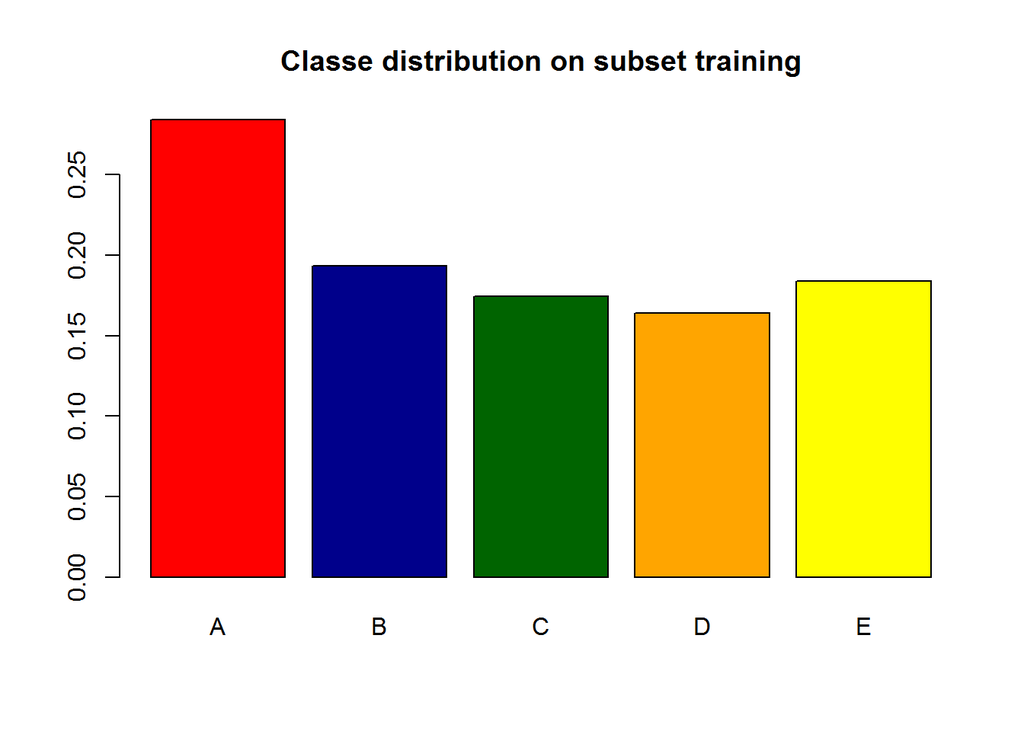

```r
barplot(prop.table(table(subsetTraining$classe)), main="Classe distribution on subset training", col=c("red","darkblue","darkgreen","orange","yellow"))
```

## Random Forest model

```r
modelRF <- randomForest(classe ~. , data=subsetTraining, method="class")
predictionRF <- predict(modelRF, subsetTesting, type = "class")
confusionMatrix(predictionRF, subsetTesting$classe)
```

```
## Confusion Matrix and Statistics
##
##           Reference
## Prediction    A    B    C    D    E
##          A 1674    8    0    0    0
##          B    0 1125    5    0    0
##          C    0    6 1020    5    1
##          D    0    0    1  959    2
##          E    0    0    0    0 1079
##
## Overall Statistics
##
##                Accuracy : 0.9952
##                  95% CI : (0.9931, 0.9968)
##     No Information Rate : 0.2845
##     P-Value [Acc > NIR] : < 2.2e-16
##
##                   Kappa : 0.994
##  Mcnemar's Test P-Value : NA
##
## Statistics by Class:
##
##                      Class: A Class: B Class: C Class: D Class: E
## Sensitivity            1.0000   0.9877   0.9942   0.9948   0.9972
## Specificity            0.9981   0.9989   0.9975   0.9994   1.0000
## Pos Pred Value         0.9952   0.9956   0.9884   0.9969   1.0000
## Neg Pred Value         1.0000   0.9971   0.9988   0.9990   0.9994
## Prevalence             0.2845   0.1935   0.1743   0.1638   0.1839
## Detection Rate         0.2845   0.1912   0.1733   0.1630   0.1833
## Detection Prevalence   0.2858   0.1920   0.1754   0.1635   0.1833
## Balanced Accuracy      0.9991   0.9933   0.9958   0.9971   0.9986
```

Random Forest model accuracy is 99.52%

## Decision Tree model

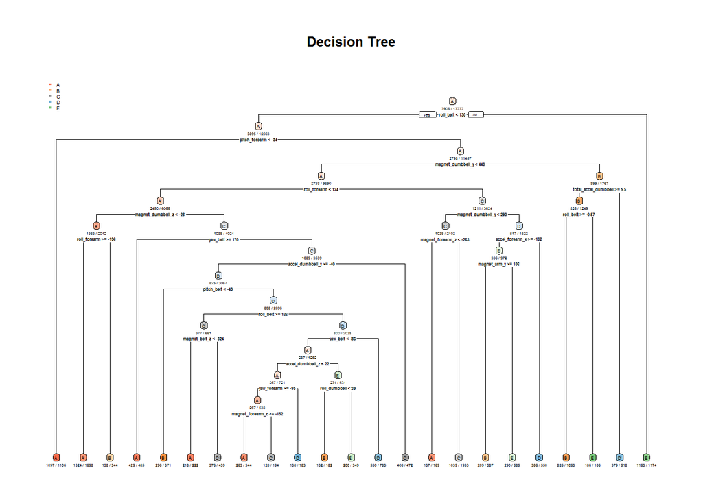

```r
modelDT <- rpart(classe ~. , data=subsetTraining, method="class")
rpart.plot(modelDT, main="Decision Tree", extra=2, under=TRUE, faclen=0)
```

```r
predictionDT <- predict(modelDT, subsetTesting, type = "class")
confusionMatrix(predictionDT, subsetTesting$classe)
```

```
## Confusion Matrix and Statistics
##
##           Reference
## Prediction    A    B    C    D    E
##          A 1471  163   20   38   14
##          B   42  691   88   96  112
##          C   62  159  836  163  146
##          D   67   84   53  574   58
##          E   32   42   29   93  752
##
## Overall Statistics
##
##                Accuracy : 0.7347
##                  95% CI : (0.7233, 0.746)
##     No Information Rate : 0.2845
##     P-Value [Acc > NIR] : < 2.2e-16
##
##                   Kappa : 0.6644
##  Mcnemar's Test P-Value : < 2.2e-16
##
## Statistics by Class:
##
##                      Class: A Class: B Class: C Class: D Class: E
## Sensitivity            0.8787   0.6067   0.8148  0.59544   0.6950
## Specificity            0.9442   0.9288   0.8909  0.94676   0.9592
## Pos Pred Value         0.8623   0.6715   0.6120  0.68660   0.7932
## Neg Pred Value         0.9514   0.9077   0.9580  0.92276   0.9332
## Prevalence             0.2845   0.1935   0.1743  0.16381   0.1839
## Detection Rate         0.2500   0.1174   0.1421  0.09754   0.1278
## Detection Prevalence   0.2899   0.1749   0.2321  0.14206   0.1611
## Balanced Accuracy      0.9115   0.7677   0.8529  0.77110   0.8271
```

Decision Tree model accuracy is 73.47%

## Prediction on Test Data

Due the high accuracy of 99.52%, the Random forests model will be applied on the testing set.

```r
predict(modelRF,testingSet,type = "class")
```

```
##  1  2  3  4  5  6  7  8  9 10 11 12 13 14 15 16 17 18 19 20
##  B  A  B  A  A  E  D  B  A  A  B  C  B  A  E  E  A  B  B  B
## Levels: A B C D E
```